# Unsupervised Learning: Trade & Ahead

## Dimensionality Reduction using PCA for visualization

```python
# importing library
from sklearn.decomposition import PCA

# setting the number of components to 2
pca = PCA(n_components=2)

# transforming data and storing results in a dataframe
X_reduced_pca = pca.fit_transform(hc_df)
reduced_df_pca = pd.DataFrame(
    data=X_reduced_pca, columns=["Component 1", "Component 2"]
)
```

```python
# checking the amount of variance explained
pca.explained_variance_ratio_.sum()
```

```
0.3717191996354095
```

- The first two principal components explain 37.17% of the variance in the data.

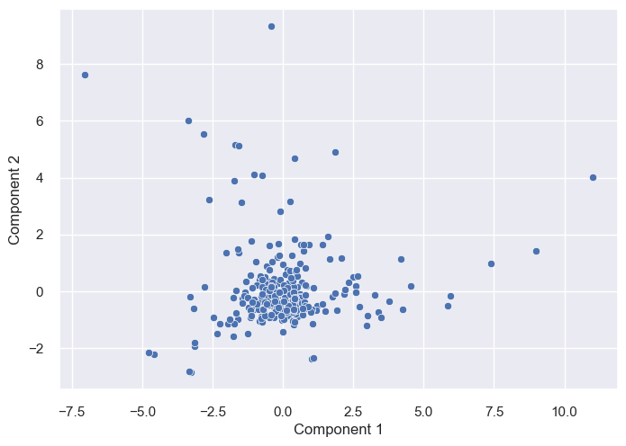

```python
sns.scatterplot(data=reduced_df_pca, x="Component 1", y="Component 2")
```

- There is one (1) very well defined cluster, with what looks to be outliers.
- Possibly another loose cluster where Component 2 > 2 and Component 1 < 2.5
- Possibly another loose cluster where Component 1 > 2.5

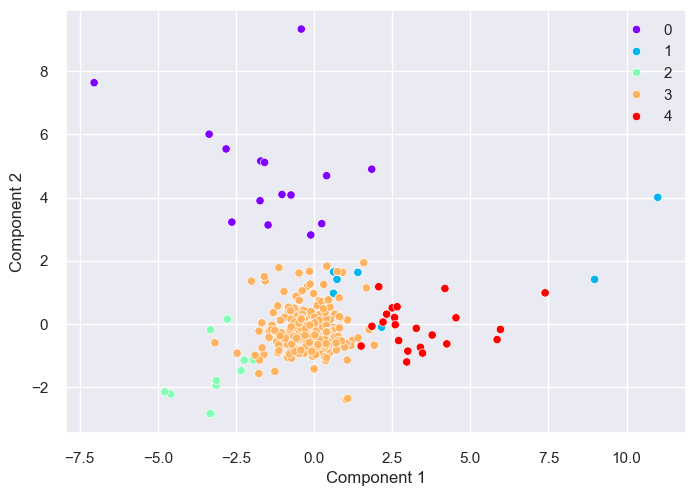

```python
# Create a scatter plot with Hue values to show the clusters for the two component values.
sns.scatterplot(
    data=reduced_df_pca,
    x="Component 1",
    y="Component 2",
    hue=df2["HC_segments"],
    palette="rainbow",
)
plt.legend(bbox_to_anchor=(1, 1))
```

```python
# Let's try PCA with n_components=3 to see if it will explain a much higher amount; while still visualizing with a 3D model.
# importing library
from sklearn.decomposition import PCA

# setting the number of components to 3
pca = PCA(n_components=3)

# transforming data and storing results in a dataframe
X_reduced_pca = pca.fit_transform(hc_df)
reduced_df_pca = pd.DataFrame(
    data=X_reduced_pca, columns=["Component 1", "Component 2", "Component 3"]
)
```

```python
# checking the amount of variance explained
pca.explained_variance_ratio_.sum()
```

```
0.4914722248538328
```

- The first three (3) principal components explain 49.15% of the variance in the data.

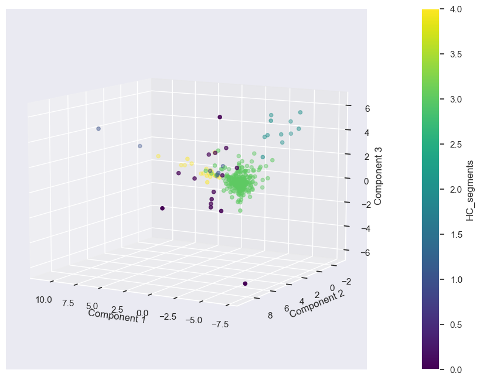

```python
# Create a 3D plot
fig = plt.figure(figsize=(12, 8))
ax = fig.add_subplot(111, projection='3d')

# Plot the scatter plot
sc=ax.scatter(
    reduced_df_pca["Component 1"],
    reduced_df_pca["Component 2"],
    reduced_df_pca["Component 3"],
    c=df2["HC_segments"],
    cmap='viridis'
)

# Create a colorbar
cbar = plt.colorbar(sc, ax=ax, pad=0.1)
cbar.set_label('HC_segments')

# Set labels
ax.set_xlabel('Component 1')
ax.set_ylabel('Component 2')
ax.set_zlabel('Component 3')

#Change the projection point
ax.view_init(elev=10, azim=120)  # Set elevation and azimuth


plt.show()
```

## K-means vs Hierarchical Clustering

You compare several things, like:

- Which clustering technique took less time for execution?
- Which clustering technique gave you more distinct clusters, or are they the same?
- How many observations are there in the similar clusters of both algorithms?
- How many clusters are obtained as the appropriate number of clusters from both algorithms?

You can also mention any differences or similarities you obtained in the cluster profiles from both the clustering techniques.

### Comparison of K-menas vs Hierarchical Clustering

- KMeans clustering took less time to execute than the Hierarchical clustering
- Both techniques appeared to offer about the same number of clusters with similar levels of distinctions. However, the KMeans clustering may have a little more securities represented in each cluster.
- KMeans created 6 clusters.
- Hierarchical Clustering created 5 clusters.
- Below are the various observations for each cluster per clustering strategy:
- KMeans clustering with k=6
  - Cluster 0: 14 companies
  - Cluster 1: 37 companies
  - Cluster 2: 6 companies
  - Cluster 3: 5 companies
  - Cluster 4: 9 companies
  - Cluster 5: 269 companies
- Hierarchical Clustering: Distance=Euclidean; linkage=Ward with n_clusters=5
  - Cluster 0: 15 companies
  - Cluster 1: 7 companies
  - Cluster 2: 11 companies
  - Cluster 3: 285 companies
  - Cluster 4: 22 companies
- There were some indications that KMeans Clustering with k=5 may have also provided similar results as Hierarchial Cluster with n_clusters=5
- Attempts were made to try various Hierarchical Cluster variations of linkages with higher Cophenetic Correlation scores (such as: average and centroid). However, they did not yield better clusters.
  - Using Ward with a lower Cophenetic Correlation score offered better cluster balance, but may have been at a sacrifice of data/clustering accuracy.
- A couple of attempts were made to improve KMeans clustering algorithm for better identification of clusters:
  - Created new metrics/ratios using existing features
    - These new features didn't result in new clusters; nor were they more balanced.
  - Converted GCIS Security textual categories to numeric values:
    - Bag-of-Words clustering technique
    - ID-TDF technique
    - Note: These created 11 clusters that were aligned 1-on-1 with the GCIS Security. This didn't really provide any new insights. Abandoned these strategies.

## Actionable Insights and Recommendations

- Selected the K-means clustering over the Hierarchical Clustering, since it provided one (1) additional cluster.
- K-means also did a slightly better job at distributing securities across each of the clusters.

### Key insights

- Cluster 0
  - Has moderate volatility, a positive price change, reasonable P/E ratio, and a relatively low P/B ratio
  - Suggests it might include stocks with stable earnings, moderate cash reserves, and a significant net income.
  - The negative P/B ratio might indicate undervalued stocks relative to their book value.
- Cluster 1
  - Has a significant negative net income and earnings per share, high P/E ratio, and positive P/B ratio
  - Possibly indicating potentially high-growth stocks with volatile prices and a lower cash ratio.
  - The negative net income suggests these stocks might be struggling financially.
- Cluster 2
  - Exhibits extreme volatility and a very high ROE, despite having negative net income and earnings per share.
  - The high P/E ratio suggests investor expectations for future earnings, but the negative cash flow and low cash ratio indicate financial instability.
  - The low P/B ratio might indicate undervaluation.
- Cluster 3
  - Has the highest positive price change and ROE.
  - Has moderate volatility, positive net income, and positive earnings per share.
  - The negative P/B ratio suggests potential undervaluation relative to book value.
  - The moderate P/E ratio indicates a mix of growth potential and current earnings stability.
- Cluster 4
  - Represents stocks with high current prices, moderate volatility, moderate ROE, and positive earnings metrics.
  - Has the highest cash ratios, earnings per share, and P/E ratios.
  - The high P/E ratio and P/B ratio suggest these stocks might be considered growth stocks with strong market valuations relative to their earnings and book values.
- Cluster 5
  - Consists of stocks with moderate volatility, positive ROE, positive net income, and earnings per share.
  - The positive P/E ratio and negative P/B ratio suggest these stocks might be undervalued, but could also mean a sign of financial distress.

### Overall insights

- **Growth Potential**: Recommend investments in cluster 4 securities for growth potential. However, be cautious of the high valuations.
- **Value Investing**: Recommend investments in cluster 0, 3, and 5 securities for value investments; since they have positive earnings and low P/B ratios. However, do due deligence to ensure these stocks are indeed undervalued and not going through any financial distress.
- **Balance Risk and Volatility**: Recommend allocating investments across different clusters to balance risk and volatility. For example, recommending stocks in clustrers 0 and 5 bring stable earnings and moderate volatility. While also investing in high growth stocks from cluster 4 can bring a balanced portfolio.